# Data Privacy Survey

Results for the Science faculty

Dorien Huijser

Version: 2022-08-15

Abstract

In the second quarter of 2022, Utrecht University (UU) Research Data Management Support (RDM Support) sent out a survey among all scientific personnel at UU: the Data Privacy Survey. The aim of this survey was to investigate 1) How UU researchers currently deal with personal data in research, 2) What challenges they run into when handling personal data in research, and 3) How support at UU can improve their services concerning personal data in research. The current report summarises the results from respondents from the Science faculty.

# Introduction

The Data Privacy Survey was conducted in 2022 at Utrecht University (UU) Research Data Management Support (RDM Support), as part of a larger project, the [Data Privacy Project](https://utrechtuniversity.github.io/dataprivacyproject). It aimed to find out:

1. To what extent are UU researchers aware of privacy legislation and practices?
2. What data privacy issues do UU researchers typically run into?
3. What support do UU researchers need to handle personal data in their research?

These questions were investigated through an online survey and subsequent one-on-one meetings with researchers, who indicated to be willing to speak with us about the topic of handling personal data in research. The full report of this survey can be read in the university-wide report.

As every UU faculty is organised somewhat differently, privacy-related experiences of UU researchers may also depend heavily on the faculty where they perform their research. Therefore, here we created an additional report for the Science faculty, the largest faculty at the university.

# Methods

The full methods are described in the UU-wide report. Below is a summary of the details specific to the Science faculty.

## Online survey respondents

There were 44 respondents from the Science faculty in the online survey. It took them a median of 5.7 minutes to complete it (ranging from 0.6 minutes to 5.1 days). In the graph below, the representation of each department within the Science faculty is visualised.

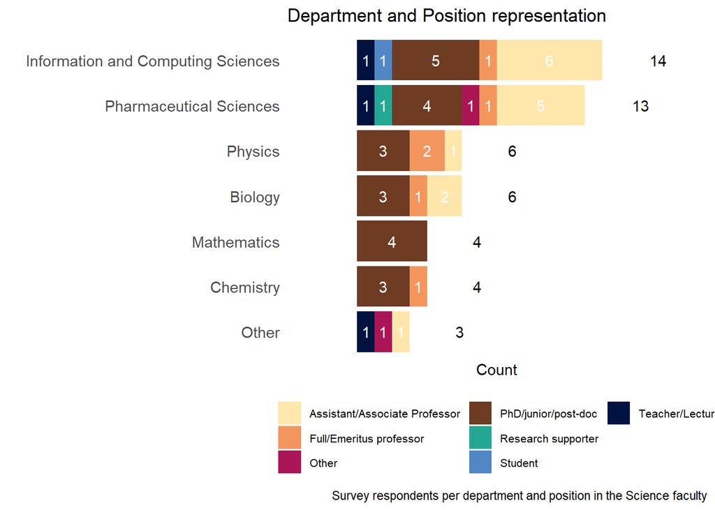

Most respondents in the online survey seemed to come from the Information and Computing Sciences (ICS) and Pharmaceutical Sciences departments, and were relatively early career researchers (PhD/junior/postdoc researcher, assistant/associate professor). This makes sense, as more personal data is likely processed in the fields of ICS and pharmaceuticals, compared to, for example, mathematics.

## One-on-one meetings

From the survey respondents, 7 researchers from the Science faculty left their email address to be contacted, although not all researchers indicated to be willing to meet with us when contacted. So far, 7 online meetings have been conducted, each taking about 30 minutes, and each with the project coordinators.

Below, the division over positions can be seen for all interviewees from the Science faculty.

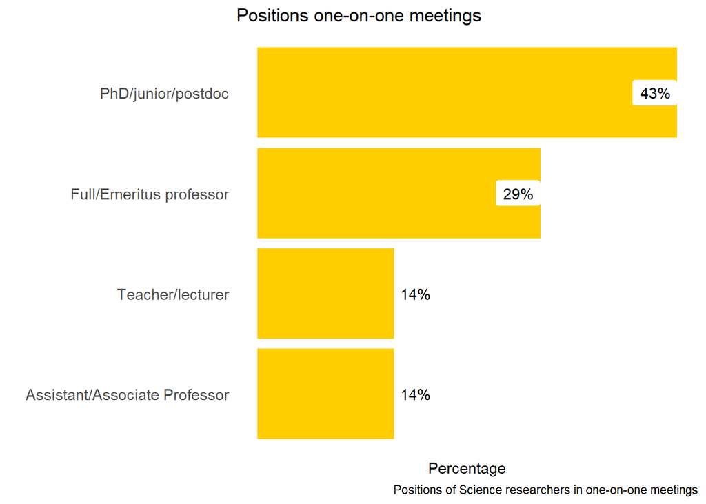

# Results

## Types of research data

As with the university-wide data, researchers from the Science faculty indicated that they also most often used tabular data, textual data and code/theoretical models in their research. The same goes for the types of *personal* data: the same top-3 types are used here as in the entire university (demographic information, contact information, direct identifiers).

**Types of data used**

| Datatype | Frequency |
| --- | --- |
| Tabular data | 34 (77.3%) |
| Textual data | 27 (61.4%) |
| Code/theoretical models | 24 (54.5%) |
| Images | 13 (29.5%) |
| Video data | 9 (20.5%) |
| Bio-medical samples and data | 8 (18.2%) |
| Audio data | 8 (18.2%) |
| Physical samples | 6 (13.6%) |
| Physiological measurements | 5 (11.4%) |
| Geographical data | 4 (9.1%) |
| Other | 2 (4.5%) |

**Types of *personal* data used**

| Personal Datatype | Frequency |
| --- | --- |
| Demographic information | 17 (38.6%) |
| Direct identifiers | 13 (29.5%) |
| Contact information | 13 (29.5%) |
| None | 12 (27.3%) |
| Derived personal data | 11 (25%) |
| Human behaviour | 9 (20.5%) |
| Health/physical information | 8 (18.2%) |
| Sensitive direct identifiers | 4 (9.1%) |
| Sensitive demographic information | 4 (9.1%) |
| Other | 2 (4.5%) |

As a large part of the researchers from the Science faculty indicated not to use *any* personal data whatsoever in their research, it may be useful to investigate in which departments these researchers work. In the figure below, the division of personal data types per Science department is plotted. As can be expected, the departments of Biology, Physics and Mathematics do not seem to process much personal data, whereas in the Information and Computing Sciences and Pharmaceutical Sciences departments, the most personal data is processed. This makes sense considering the types of research performed in these departments.

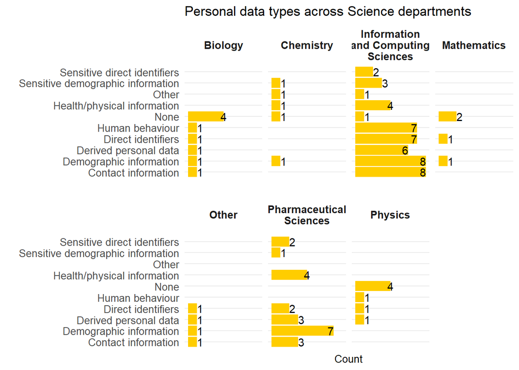

## Current practices

The first part of the survey addressed the researchers’ current practices in handling personal data in their research.

### Organisational and technical measures

With respect to organisational and technical measures used to handle personal data, most respondents in the Science faculty indicated that they pseudonymise/anonymise their data, use access control, and fill out a Data Management Plan (DMP). These results are comparable to the university-wide results.

Notably, most responses to this and upcoming questions seem to be filled out primarily by researchers from the ICS and Pharmaceutical Sciences departments. It is possible that researchers from the other departments did not answer these questions, as they do not process a lot of personal data in their research, and may have simply skipped these questions.

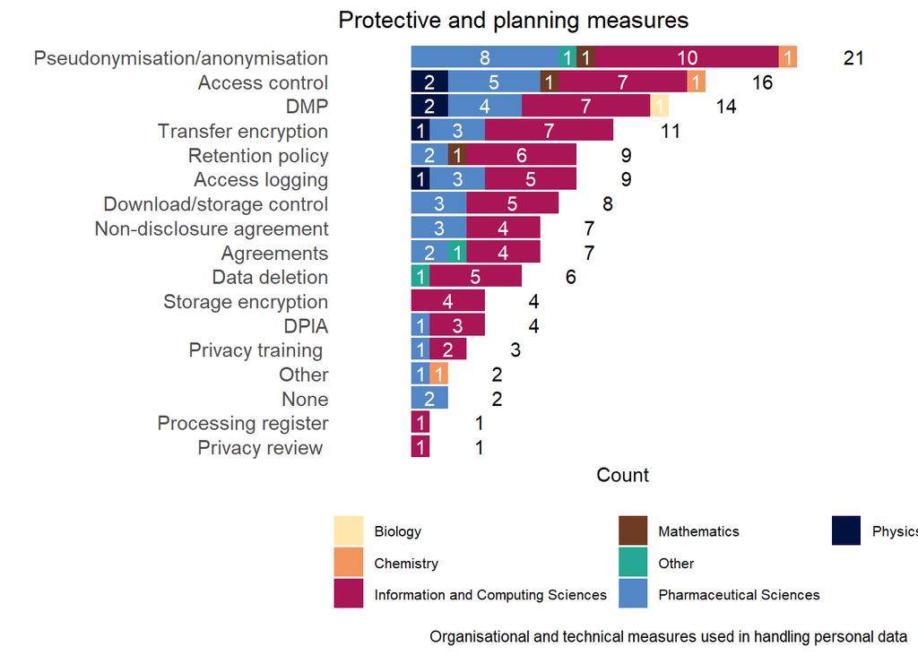

### Storage media used

The majority of respondents from the Science faculty indicated to use a UU-provided or -approved storage medium (both cloud and network solutions) for storing personal data. This is good news as these are the facilities that are safe to use. As with the university-wide results, other facilities were also sometimes used, including those not recommended by UU. Respondents who filled out those non-recommended responses got a warning to take a critical look at their choice of storage media before moving on to the next survey question. In one of the one-on-one interviews with a Science researcher, we learned that this researcher had taken this advice from the warning to heart and had switched to a UU-recommended storage facility instead.

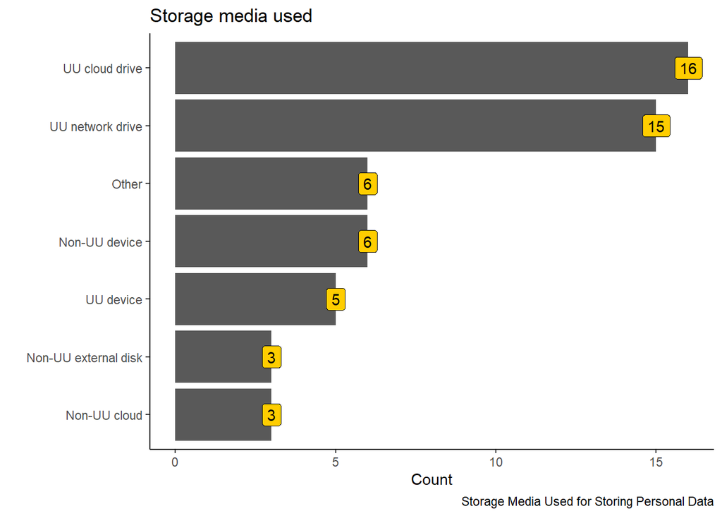

### Consent forms: usage and content

In the below graph the responses to the questions about consent forms are displayed. They make clear that most researchers at the Science faculty use a consent form that is approved by a privacy expert or ethical committee, but also that part of the respondents did not use a consent form at all, or wrote it themselves. This is a bit worrying, as consent is at the moment of writing the legal basis most often used for research performed at UU, and writing one may take expertise that researchers do not always have (nor do they need to have it).

When a consent form is used, the information provided to data subjects does seem to be relatively complete, as indicated by the division of responses to this question: many components of this (multiple responses) question seem to be present. Only contact details of the Data Protection Officer (DPO) and information and consent for further processing and sharing the data for reuse is not regularly included.

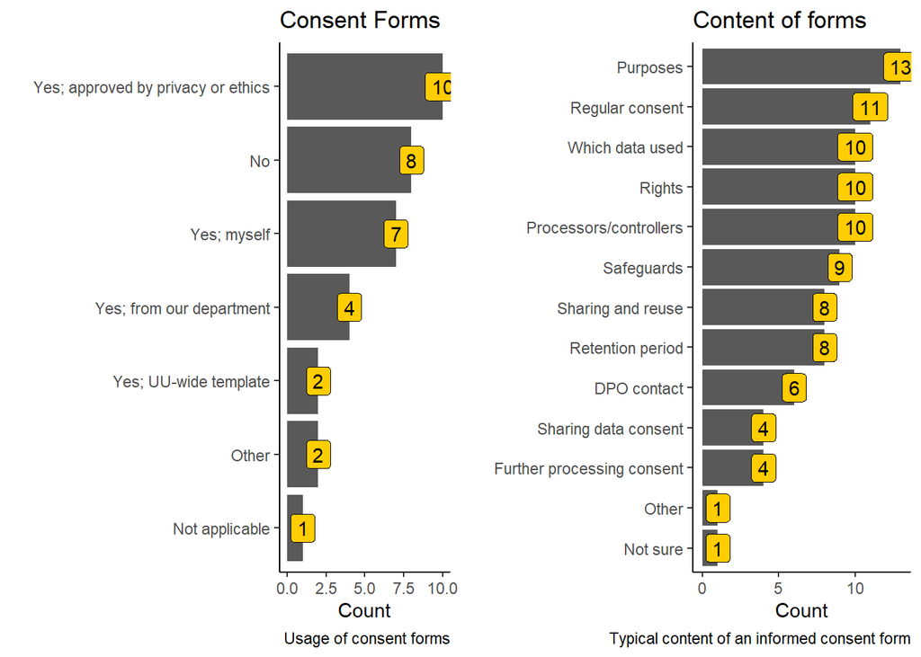

### Data Protection Impact Assessment (DPIA)

There does not seem to be much experience with performing DPIAs at the Science department: most researchers indicated not to have performed any, nor to have heard from it. Those that did perform a DPIA did not always get help from a privacy officer. This could be interpreted as problematic, however, it is also possible that there was no privacy officer available yet when these researchers performed their DPIA, or that they got help from someone with similar expertise, but without the title of “privacy officer”.

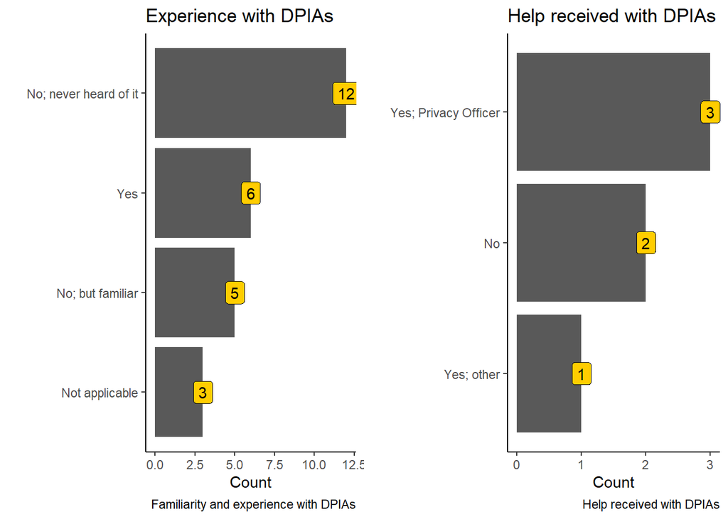

### Data sharing practices

It appears that data are not much shared externally by researchers within the Science faculty. Those that did indicate to share data, used mostly pseudonymisation, approved tools, and agreements to protect the personal data.

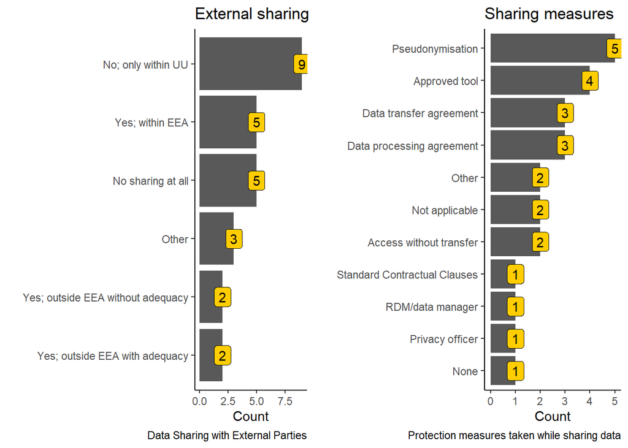

### Data publishing

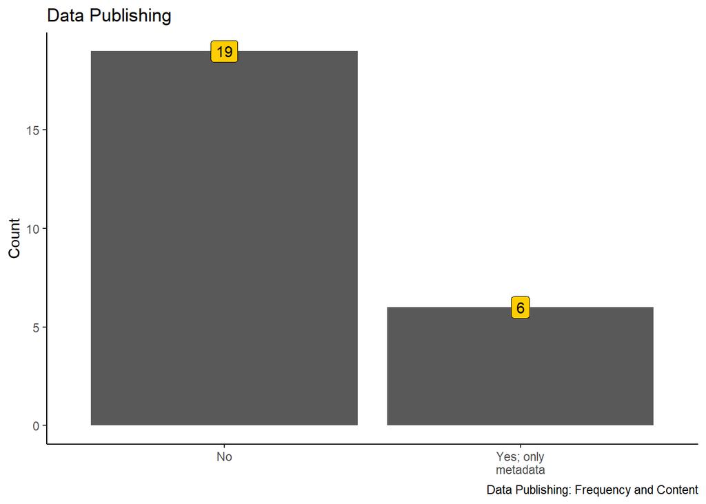

Datasets containing personal data also do not seem to be published at all, or only the metadata (i.e., contextual information about the project, which usually only contains personal information from the researchers themselves). The main reasons for this seems to be that researchers simply felt they did not need to do so, or (thought that they) had no legal basis to do so.

[figure not shown]

## Existing support channels

### Faculty privacy officer

When comparing departments (see below), it is striking that even in the departments where most personal data are processed in research, a large part of the respondents do not seem to know the faculty privacy officer. This suggests either that researchers have simply never required help from their privacy officer, or that the faculty privacy officer could increase their visibility within the faculty.

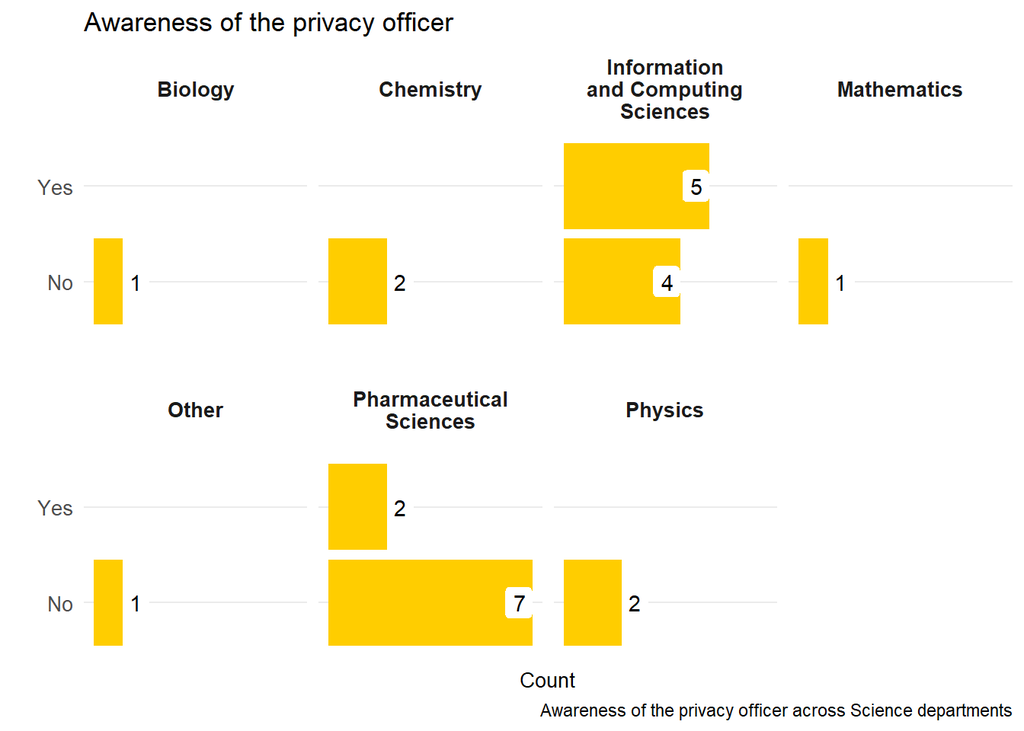

### Looking for help

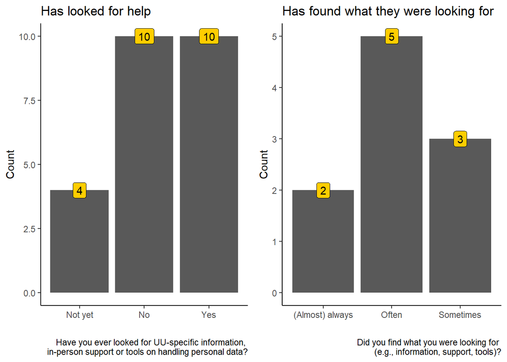

### Channels used to find support

The graph below indicates which channels respondents used most when looking for information about handling personal data. Strikingly, researchers at the Science faculty seemed to rely most on direct colleagues, rather than available trainings and specific websites. This is in contrast with the university-wide results, where the UU website and intranet scored the highest. This suggests that in-person support may be a more effective way of increasing awareness of privacy-related practices than more “distant” information sources.

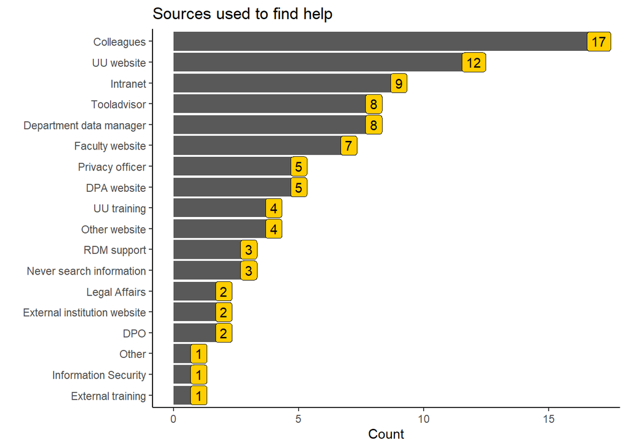

## Challenges and needs (survey) {#challenges-needs-survey}

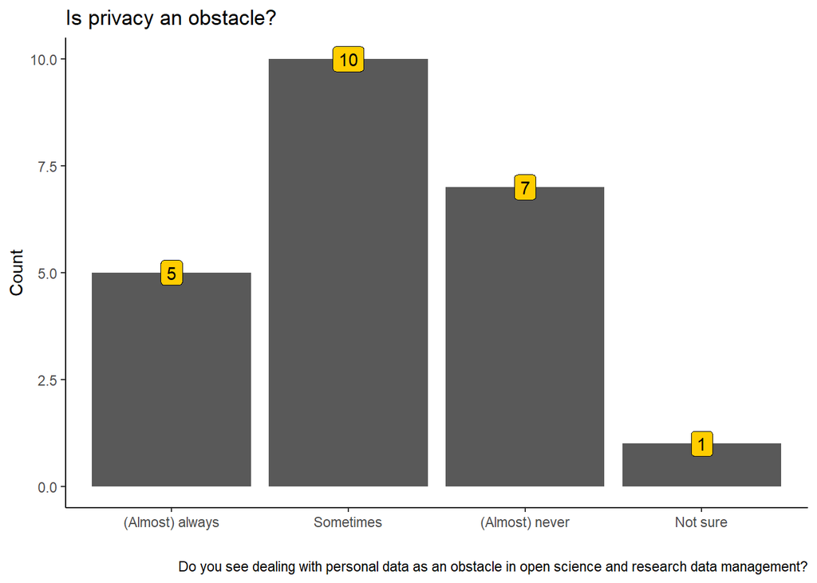

As can be seen above, most Science researchers experience privacy to be an obstacle for open science and research data management in some way. It is therefore important to aim for support in this area. According to the respondents in the Science faculty, this support would be best improved by increasing the visibility of available support, improving or increasing the information about handling personal data in research, and drawing up a UU-wide policy on handling personal data in research.

How can we improve personal data-related services?

| bettersupport | Count | Percentage |
| --- | --- | --- |
| Support visibility | 15 | 34.1 |
| Information | 13 | 29.5 |
| UU-wide policy | 10 | 22.7 |
| Tooling | 5 | 11.4 |
| Workshops | 4 | 9.1 |
| Walk-ins | 4 | 9.1 |
| Trainings | 4 | 9.1 |
| Support availability | 4 | 9.1 |
| Other | 4 | 9.1 |

## Challenges and needs (open questions, one-on-one meetings)

The codes that were assigned in both the survey and the meeting notes can be seen in the word cloud below: the larger the font, the more often the code was assigned. Please note that there is overlap in respondents between the open questions in the survey and the meeting notes, and therefore some codes may have been applied twice for the same researcher.

[interactive chart not shown]

**Below we go into the most frequently mentioned challenges/needs expressed by researchers at the Science faculty in the survey (open questions) and one-one-one meetings:**

### Specific tools

The need for specific tools was mentioned by 10 Science researchers. There was however wide variation in the type of tools requested. Most tools related to pseudonymising data in some way, for example qualitative data or video data. Here’s the top 3:

- Deidentifying or pseudonymising personal data (general) (mentioned 2 times)
- Speech-to-text conversion tool (mentioned 2 times)
- Solution to analyse data in spss via onedrive instead of having to download the data locally first (mentioned 1 times)

Besides these tools, a selection of researchers also indicated that they would like to be able to use templates for frequent privacy-related documentation (3 times). One example would be a template DPIA, pre-filled for specific types of research, which requires only minimal effort to adjust to a specific research project.

### Hands-on support

Similar to the university-wide results, a selection of Science researchers (6) also indicated to have a need for more hands-on support, that is support that helps researchers more concretely and clings less to the letter of the law (mentioned 2 times)in favor of providing practical solutions.

### Visibility and availability

Visibility of the available support was also mentioned regularly by Science researchers (visibility mentioned 6 times, availability 3 times). Combined with the fact that Science researchers seemed to ask their direct colleagues a lot when looking for support, increasing the awareness of available data management and privacy-related expertise may need to be prioritised.

### Less bureaucracy

Some researchers at the Science faculty have apparently also faced some bureaucracy and slow processes in handling personal data in their research. These researchers mentioned that some processes should be made easier and more efficient (mentioned by 5 researchers), especially that of performing a DPIA (mentioned explicitly 3 times).

### … or simply no issues

Notably, there were also a few researchers who indicated **not** to have run into issues (yet), or to have received sufficient and useful help (3).

# Conclusion

In this report, we summarised the findings of the Data Privacy Survey, looking specifically at respondents from the faculty of Science. In short, we found that:

- Most personal data are processed in the departments of Information Computing Sciences and Pharmaceutical Sciences. The types of data are similar to that of the entire university, namely tabular and textual data and code/theoretical models. In terms of personal data, demographic information, direct identifiers and contact information were most common.
- The current practices of researchers at the Science faculty resemble those explicated in the university-wide results: most researchers are familiar with the basic concepts and most common practices (e.g., DMPs, informed consent forms, anonymisation), but other, also important, practices were less often performed, such as the DPIA, data publication, and measures such as storage encryption or the processing register.
- As there hasn’t been a privacy officer for that long of a time at the Science faculty, it is not that surprising that not all researchers are yet familiar with them. It follows that most researchers turn to each other or the internet to look for information and support. Increasing the awareness of available support, especially in the ICS and Pharmaceutical sciences departments, may be fruitful in improving the compliance of researcher performed at this faculty.

Some recommendations are already described in the section above on challenges and needs. For further recommendations, please refer to the university-wide report.